# **Natural Language Processing with Disaster Tweets ⛈**

En este notebooks, se utilizó el dataset "Natural Language Processing with Disaster Tweets" de Kaggle con el objetivo de clasificar tweets en dos categorías: desastres reales o no.

Se construyeron y evaluaron dos modelos de clasificación (LSTM) para determinar si un tweet se refiere a un desastre real. Se probaron diferentes algoritmos para comparar su rendimiento y se abordó el contexto a través del análisis de palabras clave y patrones en los datos.

**Authors:**

- [Andrea Ramirez](https://github.com/Andrea-gt)
- [Adrian Flores](https://github.com/adrianRFlores)

## **(1) Import Libraries** ⬇️

```python
#!pip install unidecode
```

```python
#!pip install nlpaug
```

```python
#!pip install wordcloud
```

```python
# Data manipulation and visualization
import matplotlib.pyplot as plt
import numpy as np
import pandas as pd
import seaborn as sns
from scipy.stats import kurtosis, skew, probplot
from sklearn.metrics import mean_absolute_error, mean_squared_error
import statsmodels.api as sm
import itertools
import re
import nltk
from nltk.corpus import stopwords
from nltk.stem import PorterStemmer
from unidecode import unidecode
import tensorflow as tf
from tensorflow import keras
from google.colab import files

# Standard libraries
import warnings
warnings.filterwarnings('ignore')

# ===== ===== Reproducibility Seed ===== =====
# Set a fixed seed for the random number generator for reproducibility
random_state = 42

# Set matplotlib inline
%matplotlib inline

# Set default figure size
plt.rcParams['figure.figsize'] = (6, 4)

# Define custom color palette
palette = sns.color_palette("viridis", 12)

# Set the style of seaborn
sns.set(style="whitegrid")
```

## **(2) Data Upload** 📄

```python
df = pd.read_csv('data/train.csv')
df.head()
```

|  | id | keyword | location | text | target |
| --- | --- | --- | --- | --- | --- |
| 0 | 1 | NaN | NaN | Our Deeds are the Reason of this #earthquake M... | 1 |
| 1 | 4 | NaN | NaN | Forest fire near La Ronge Sask. Canada | 1 |
| 2 | 5 | NaN | NaN | All residents asked to 'shelter in place' are ... | 1 |
| 3 | 6 | NaN | NaN | 13,000 people receive #wildfires evacuation or... | 1 |
| 4 | 7 | NaN | NaN | Just got sent this photo from Ruby #Alaska as ... | 1 |

## **(3) Exploratory Analysis** 🔎

### **(1) Descripción General de los Datos**

```python
# Print the number of records in the DataFrame
print("The given dataset has", df.shape[0], "registers and", df.shape[1], "columns.")
```

```
The given dataset has 7613 registers and 5 columns.
```

**Observaciones 💡 -->**

> - El conjunto de datos original cuenta con 7613 registros y 5 columnas, lo que indica que tiene una dimensión relativamente pequeña. Cada uno de los 7613 registros representa una observación única, mientras que las 5 columnas corresponden a diferentes características o variables medidas para cada observación, incluyendo el texto de un tweet, una palabra clave asociada y la ubicación desde donde se envió, aunque estas últimas dos pueden estar en blanco en algunas ocasiones.

**Fuente:** [Página oficial de Kaggle](https://www.kaggle.com/competitions/nlp-getting-started/data?select=train.csv)

```python
# Basic information about the dataset
df.info()
```

```
<class 'pandas.core.frame.DataFrame'>
RangeIndex: 7613 entries, 0 to 7612
Data columns (total 5 columns):
 #   Column    Non-Null Count  Dtype
---  ------    --------------  -----
 0   id        7613 non-null   int64
 1   keyword   7552 non-null   object
 2   location  5080 non-null   object
 3   text      7613 non-null   object
 4   target    7613 non-null   int64
dtypes: int64(2), object(3)
memory usage: 297.5+ KB
```

Como se puede observar, se cuentan con 5 columnas o features en este conjunto de datos, siendo estas las que se describen a continuación.

- **id**: un identificador único para cada tweet.
- **text**: el texto del tweet.
- **location**: la ubicación desde donde se envió el tweet (puede estar en blanco).
- **keyword**: una palabra clave particular del tweet (puede estar en blanco).
- **target**: en el archivo `train.csv` solamente, indica si un tweet es sobre un desastre real (`1`) o no (`0`).

### **(2) Clasificación de las Variables**

| **Nombre** | **Descripción** | **Tipo de variable** |
| --- | --- | --- |
| **id** | Un identificador único para cada tweet | Cuantitativa |
| **text** | El texto del tweet | Cualitativa (descriptiva) |
| **location** | La ubicación desde donde se envió el tweet | Cualitativa (descriptiva) |
| **keyword** | Una palabra clave particular del tweet | Cualitativa (descriptiva) |
| **target** | Indica si un tweet es sobre un desastre real o no | Cualitativa (binaria) |

**Observaciones 💡 -->**

### **(3) Exploración y Limpieza Inicial de los Datos**

#### **(1) Preprocesamiento de los Datos**

```python
df.drop(columns=['id'], inplace=True)
```

```python
# Download the NLTK stopwords if not already available
nltk.download('stopwords')
# Initialize the PorterStemmer
stemmer = PorterStemmer()
```

```python
# Get the list of stopwords from NLTK
stop_words = set(stopwords.words('english'))
```

```python
# Function to remove stopwords and apply stemming
def preprocess_text(text):
    # Tokenize the text
    words = text.split()
    # Remove stopwords and apply stemming
    processed_words = [stemmer.stem(word) for word in words if word not in stop_words]
    # Reassemble the text
    return ' '.join(processed_words)
```

```python
# Convert all entries to strings
df['text'] = df['text'].astype(str)
# Remove URLs
df['text'] = df['text'].str.replace(r'http\S+|www\S+|https\S+', '', case=False, regex=True)
# Convert to lowercase
df['text'] = df['text'].str.lower()
# Remove leading/trailing whitespaces
df['text'] = df['text'].str.strip()
# Remove special characters and punctuation (keeping letters, numbers, and spaces)
df['text'] = df['text'].str.replace(r'[^\w\s]', '', regex=True)
# Remove extra spaces
df['text'] = df['text'].str.replace(r'\s+', ' ', regex=True)
# Apply preprocessing (stopwords removal and stemming)
df['text'] = df['text'].apply(preprocess_text)
```

```python
df.isnull().sum()
```

|  | 0 |
| --- | --- |
| keyword | 61 |
| location | 2533 |
| text | 0 |
| target | 0 |

**dtype:** int64

```python
# Converting the column to a list
column_to_list = df['location'].unique().tolist()
# Convert all elements to strings to avoid TypeError
column_to_list_str = [str(location) for location in column_to_list]

# === WARNING ====
# The detailed listing of unique locations has been commented out to maintain a clean notebook interface.
# If a comprehensive view is required, please uncomment the following lines:
# print("Unique Locations:")
# print(", ".join(column_to_list_str))

print(f"\nTotal number of unique locations: {len(column_to_list_str)}")
```

```
Total number of unique locations: 3342
```

```python
df = df.drop(['location'],axis=1)
```

```python
# Drop rows where 'keyword' column has NaN values
df = df.dropna(subset=['keyword'])
```

```python
# Check duplicate rows in dataset
df = df.drop_duplicates()
# Print the number of records in the DataFrame
print("The given dataset has", df.shape[0], "registers and", df.shape[1], "columns.")
```

```
The given dataset has 6940 registers and 3 columns.
```

**Observaciones 💡 -->**

**Nota:**

1. El **stemmer** reduce las palabras a su raíz o forma básica, lo que permite agrupar diferentes variaciones de una misma palabra bajo una única representación. Esto no solo disminuye la dimensionalidad del conjunto de datos haciendo que sea más fácil procesar este, sino que también mejora la capacidad de los algoritmos para identificar patrones relevantes en el texto. [[Referencia]](https://www.geeksforgeeks.org/introduction-to-stemming/)
2. Por otro lado, la eliminación de **stopwords** filtra palabras comunes que, aunque frecuentes, aportan poco valor semántico al análisis, como "y", "el", "en", entre otras. Al excluir estas palabras, se enfoca el modelo en términos más significativos, lo que puede resultar en una mejora notable en la precisión y eficiencia del análisis textual. Sin embargo, el beneficio más grande es la reducción de dimensionalidad, permitiendo que el entrenamiento sea más rápido. [[Referencia]](https://towardsdatascience.com/text-pre-processing-stop-words-removal-using-different-libraries-f20bac19929a)
3. Para algunas de las tareas de procesamiento de lenguaje natural descritas con anterioridad, se optó por implementar nltk, para más información por favor ingresar a la documentación oficial en el siguiente [enlace](https://www.nltk.org/).

#### **(2) Exploración de los Datos**

```python
# Calculate the length of text entries in the 'text' column.
length = df["text"].apply(len)
# Display descriptive statistics of text lengths.
print("Training Set: Text Length Statistics")
print(length.describe())
```

```
Training Set: Text Length Statistics
count    6940.000000
mean       58.801729
std        22.872899
min         4.000000
25%        42.000000
50%        60.000000
75%        76.000000
max       127.000000
Name: text, dtype: float64
```

**Observaciones 💡 -->**

**Tablas de Frecuencia para Cada Columna -->**

```python
# See what are the 10 most frequent values for each of the dataframe columns
for column in df.columns:
    frequency_values = df[column].value_counts().head(10)
    print("Top 10 most frequent values for column '{}':".format(column))
    for index, (value, frequency) in enumerate(frequency_values.items(), start=1):
        print("{:<5} {:<30} {:<10}".format(index, value, frequency))
    print("\n===============================================")
```

```
Top 10 most frequent values for column 'keyword':
1     fatalities                     45
2     deluge                         42
3     armageddon                     42
4     damage                         41
5     harm                           41
6     evacuate                       40
7     fear                           40
8     body%20bags                    40
9     twister                        40
10    siren                          40

===============================================
Top 10 most frequent values for column 'text':
1     angri woman openli accus nema steal relief materi meant idp angri intern displac wom 2
```

[output cut: 16 more lines]

**Word Cloud de Columna Text -->**

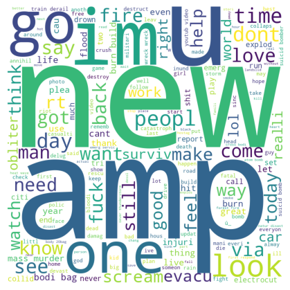

```python
from wordcloud import WordCloud

# Iterate through the 'text' column
for val in df['text']:
    # Split the sentence into words (tokens) assuming the text is already clean
    tokens = val.split()  # This will split by whitespace

    # Join the tokens back into a single string and add to comment_words
    comment_words += " ".join(tokens) + " "

# Generate the word cloud using the concatenated string of tokens
wordcloud = WordCloud(width=800, height=800,
                      background_color='white',
                      stopwords=None,  # Stopwords are assumed to be already removed
                      min_font_size=10).generate(comment_words)

# Plot the WordCloud image
plt.figure(figsize=(6, 4), facecolor=None)
plt.imshow(wordcloud)
plt.axis("off")
plt.tight_layout(pad=0)

# Show the plot
plt.show()
```

**Word Cloud de Columna Keyword-->**

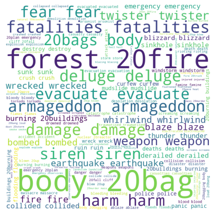

```python
# Initialize an empty string to store all keywords
comment_words = ''

# Iterate through the 'keyword' column and concatenate the keywords into a single string
for val in df['keyword']:
    comment_words += (val + " ")

# Generate the word cloud using the concatenated string of keywords
wordcloud = WordCloud(width=800, height=800,
                      background_color='white',
                      stopwords=None,  # Adjust this if you have a list of stopwords to exclude
                      min_font_size=10).generate(comment_words)

# Plot the WordCloud image
plt.figure(figsize=(6, 4), facecolor=None)
plt.imshow(wordcloud)
plt.axis("off")
plt.tight_layout(pad=0)

# Show the plot
plt.show()
```

**Análisis de Distribución de Target -->**

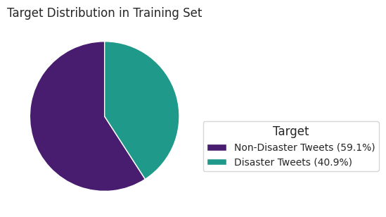

```python
# Create a figure with a single subplot
fig, ax = plt.subplots(figsize=(6, 4), dpi=100)  # Use subplots() to get the Axes object
plt.tight_layout(pad=3.0)  # Add padding around the plot

# Calculate target counts and percentages
target_counts = df['target'].value_counts()
total_count = target_counts.sum()
labels = [f'Non-Disaster Tweets ({target_counts[0]/total_count:.1%})',
         f'Disaster Tweets ({target_counts[1]/total_count:.1%})']

# Define colors from the viridis palette
colors = [palette[0], palette[6]]  # Assign specific colors to each slice

# Plot pie chart for target distribution with customized colors
wedges, texts, autotexts = ax.pie(target_counts, autopct='%1.1f%%', startangle=90, colors=colors, wedgeprops=dict(edgecolor='white'))

# Set the title
ax.set_title('Target Distribution in Training Set')

# Remove the default labels (texts)
for text in texts:
    text.set_visible(False)
for autotext in autotexts:
    autotext.set_visible(False)

# Add a legend with a specific location and size
ax.legend(wedges, labels, title='Target', loc='best', bbox_to_anchor=(1, 0.5), fontsize='small')

# Display the plot
plt.show()
```

**Observaciones 💡 -->**

> - Como es posible observar, nuestras tablas de frecuencia muestran que el conjunto de datos está desbalanceado en términos de la variable 'target': el **valor 0** (que indica la ausencia de un desastre) aparece con mucha más frecuencia (4105 casos) que el **valor 1** (que indica la presencia de un desastre) con 2835 casos. Este desbalance podría afectar el rendimiento de nuestro modelo pero primero evaluaremos su desempeño antes de tomar decisiones.
> - Para la columna keyword, esta simple tabla de frecuencia no nos dice lo suficiente así que haremos un análisis más profundo.

```python
# Pairing 0's with their most frequent keywords
target_0_keywords = df[df['target'] == 0]['keyword'].value_counts().head(10)
print("Top 10 most frequent keywords for target '0':")
for index, (keyword, frequency) in enumerate(target_0_keywords.items(), start=1):
    print(f"{index:<5} {keyword:<30} {frequency:<10}")
print("\n===============================================")

# Pairing 1's with their most frequent keywords
target_1_keywords = df[df['target'] == 1]['keyword'].value_counts().head(10)
print("Top 10 most frequent keywords for target '1':")
for index, (keyword, frequency) in enumerate(target_1_keywords.items(), start=1):
    print(f"{index:<5} {keyword:<30} {frequency:<10}")
```

```
Top 10 most frequent keywords for target '0':
1     body%20bags                    39
2     harm                           37
3     armageddon                     37
4     deluge                         36
5     ruin                           36
6     wrecked                        36
7     twister                        35
8     fear                           35
9     siren                          35
10    panic                          34

===============================================
Top 10 most frequent keywords for target '1':
1     evacuated                      31
2     debris                         31
3     earthquake                     30
4     derailment                     29
5     wildfire                       29
6     nuclear%20disaster             28
7     suicide%20bombing              28
8     evacuation                     28
9     buildings%20on%20fire          27
10    mass%20murder                  27
```

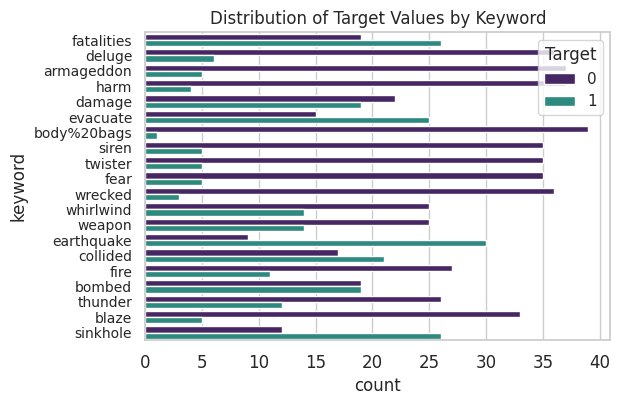

```python
# Create a figure with increased size for better visual clarity
fig = plt.figure(figsize=(6, 4), dpi=100)  # Adjusted figsize for better visual clarity

# Group by 'keyword' and calculate mean target values
grouped_df = df.groupby('keyword')['target'].transform('mean')

# Sort DataFrame by calculated mean target values
sorted_df = df.assign(mean_target=grouped_df).sort_values(by='mean_target', ascending=False)

# Optional: Display only the top N keywords for better visibility
top_n = 20
top_keywords = sorted_df['keyword'].value_counts().index[:top_n]
filtered_df = sorted_df[sorted_df['keyword'].isin(top_keywords)]

# Create a count plot with horizontal bars
sns.countplot(y='keyword', hue='target', data=filtered_df, order=top_keywords, palette=colors)

# Customize plot appearance
plt.tick_params(axis='x', labelsize=12)
plt.tick_params(axis='y', labelsize=10)
plt.legend(title='Target', loc='upper right')
plt.title('Distribution of Target Values by Keyword')

# Display the plot
plt.show()
```

**Observaciones 💡 -->**

> - Se evidencia que para el target 0, los términos más frecuentes como "body bags" "harm" y "armageddon" están relacionados con eventos graves o de alta magnitud, pero en el contexto de la ausencia de un desastre, estos podrían estar mal clasificados o reflejar un contexto de preocupación general. Por otro lado, para el target 1, palabras como "evacuated" "debris" y "earthquake" se relacionan claramente con eventos de emergencia reales.
> - En general, los bigramas o trigramas consisten en obtener los tokens o palabras consecutivas. Esta técnica está más orientadas a aplicaciones como el análisis de sentimientos o la predicción de texto, pero se considera que podría llegar a aplicarse en este contexto. Para esto, no obstante, primero es importante adquirir ¡aún más información acerca de nuestro conjunto de datos! [[Referencia]](https://www.geeksforgeeks.org/generate-bigrams-with-nltk/)

#### **(3) Análisis Visual Preliminar de los Datos**

```python
# Converting the column to a list
column_to_list = df['keyword'].unique().tolist()
# Convert all elements to strings to avoid TypeError
column_to_list_str = [str(keyword) for keyword in column_to_list]
print(f"Number of unique values in keyword = {len(column_to_list_str)}")
```

```
Number of unique values in keyword = 221
```

##### **(1) Generación de Bigramas**

```python
from nltk.util import bigrams
from nltk.util import trigrams
from nltk.tokenize import word_tokenize
from collections import Counter
```

```python
# Ensure that the necessary NLTK resources are downloaded
nltk.download('punkt')
```

```
True
```

```python
# Tokenize text and generate bigrams
def generate_bigrams(text):
    tokens = word_tokenize(text)
    return list(bigrams(tokens))  # Generate bigrams

# Function to generate trigrams
def generate_trigrams(text):
    tokens = word_tokenize(text)
    return list(trigrams(tokens))
```

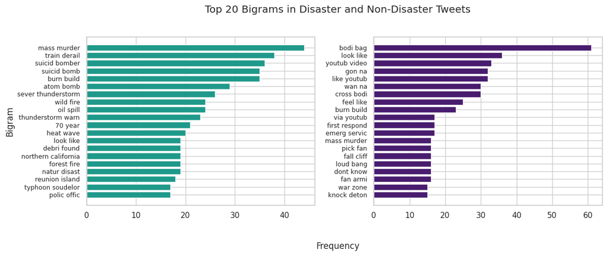

```python
# Apply bigram generation to the 'text' column and store results in a separate DataFrame
n_gram = pd.DataFrame({
    'bigrams': df['text'].apply(generate_bigrams)
})

# Separate DataFrames for disaster and non-disaster tweets
disaster_df = df[df['target'] == 1].copy()
non_disaster_df = df[df['target'] == 0].copy()

# Add bigrams to the separated DataFrames
disaster_df['bigrams'] = n_gram.loc[disaster_df.index, 'bigrams']
non_disaster_df['bigrams'] = n_gram.loc[non_disaster_df.index, 'bigrams']

# Function to count bigrams
def count_bigrams(df):
    all_bigrams = [bigram for sublist in df['bigrams'] for bigram in sublist]
    return Counter(all_bigrams)

# Count bigrams for each category
disaster_bigram_counts = count_bigrams(disaster_df)
non_disaster_bigram_counts = count_bigrams(non_disaster_df)

# Convert bigram counts to DataFrame for plotting
def bigram_counts_to_df(bigram_counts):
    bigram_df = pd.DataFrame(bigram_counts.items(), columns=['Bigram', 'Count'])
    bigram_df['Bigram'] = bigram_df['Bigram'].apply(lambda x: ' '.join(x))  # Convert tuple to string
    return bigram_df.sort_values(by='Count', ascending=False).head(20)  # Display top 20 bigrams

# Get top bigrams for each category
disaster_bigram_df = bigram_counts_to_df(disaster_bigram_counts)
non_disaster_bigram_df = bigram_counts_to_df(non_disaster_bigram_counts)

# Create plots
fig, axes = plt.subplots(ncols=2, figsize=(12, 5), dpi=100)
plt.tight_layout(pad=4.0)

# Plot for disaster tweets
axes[0].barh(disaster_bigram_df['Bigram'], disaster_bigram_df['Count'], color=colors[1])
axes[0].set_ylabel('Bigram')
axes[0].invert_yaxis()  # Invert y-axis to have the most frequent bigram on top
axes[0].tick_params(axis='y', labelsize=9)  # Set fontsize for y-tick labels

# Plot for non-disaster tweets
axes[1].barh(non_disaster_bigram_df['Bigram'], non_disaster_bigram_df['Count'], color=colors[0])
axes[1].invert_yaxis()  # Invert y-axis to have the most frequent bigram on top
axes[1].tick_params(axis='y', labelsize=9)  # Set fontsize for y-tick labels

# Set a common title and x-axis label for the entire figure
fig.suptitle('Top 20 Bigrams in Disaster and Non-Disaster Tweets')
fig.supxlabel('Frequency', fontsize=12)

# Display the plots
plt.show()
```

##### **(1) Generación de Trigramas**

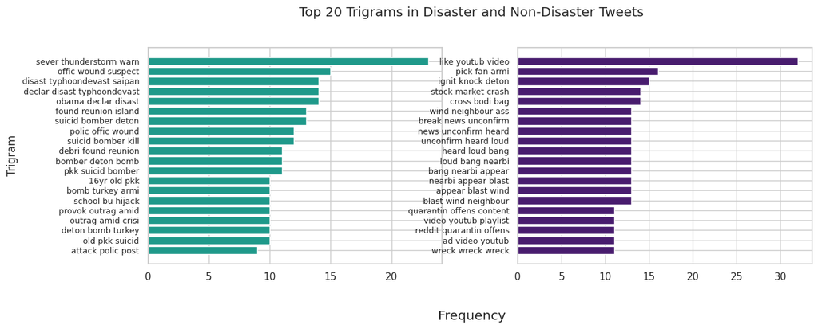

```python
# Apply trigram generation to the 'text' column and store results in a separate DataFrame
n_gram = pd.DataFrame({
    'trigrams': df['text'].apply(generate_trigrams)
})

# Separate DataFrames for disaster and non-disaster tweets
disaster_df = df[df['target'] == 1].copy()
non_disaster_df = df[df['target'] == 0].copy()

# Add trigrams to the separated DataFrames
disaster_df['trigrams'] = n_gram.loc[disaster_df.index, 'trigrams']
non_disaster_df['trigrams'] = n_gram.loc[non_disaster_df.index, 'trigrams']

# Function to count trigrams
def count_trigrams(df):
    all_trigrams = [trigram for sublist in df['trigrams'] for trigram in sublist]
    return Counter(all_trigrams)

# Count trigrams for each category
disaster_trigram_counts = count_trigrams(disaster_df)
non_disaster_trigram_counts = count_trigrams(non_disaster_df)

# Convert trigram counts to DataFrame for plotting
def trigram_counts_to_df(trigram_counts):
    trigram_df = pd.DataFrame(trigram_counts.items(), columns=['Trigram', 'Count'])
    trigram_df['Trigram'] = trigram_df['Trigram'].apply(lambda x: ' '.join(x))  # Convert tuple to string
    return trigram_df.sort_values(by='Count', ascending=False).head(20)  # Display top 20 trigrams

# Get top trigrams for each category
disaster_trigram_df = trigram_counts_to_df(disaster_trigram_counts)
non_disaster_trigram_df = trigram_counts_to_df(non_disaster_trigram_counts)

# Create plots
fig, axes = plt.subplots(ncols=2, figsize=(12, 5), dpi=100)
plt.tight_layout(pad=4.0)

# Plot for disaster tweets
axes[0].barh(disaster_trigram_df['Trigram'], disaster_trigram_df['Count'], color=colors[1])
axes[0].set_ylabel('Trigram')
axes[0].invert_yaxis()  # Invert y-axis to have the most frequent trigram on top
axes[0].tick_params(axis='y', labelsize=9)  # Set fontsize for y-tick labels

# Plot for non-disaster tweets
axes[1].barh(non_disaster_trigram_df['Trigram'], non_disaster_trigram_df['Count'], color=colors[0])
axes[1].invert_yaxis()  # Invert y-axis to have the most frequent trigram on top
axes[1].tick_params(axis='y', labelsize=9)  # Set fontsize for y-tick labels

# Set a common title and x-axis label for the entire figure
fig.suptitle('Top 20 Trigrams in Disaster and Non-Disaster Tweets')
fig.supxlabel('Frequency')

# Display the plots
plt.show()
```

**Observaciones 💡 -->**

> - En el análisis, se generaron bigramas y trigramas a partir de los tweets para estudiar las combinaciones más frecuentes de palabras en los mensajes clasificados como desastres y no desastres. Primero, se tokenizó el texto de cada tweet, dividiéndolo en palabras individuales. Luego, se formaron bigramas y trigramas, que son secuencias consecutivas de dos o tres palabras, respectivamente. Estos n-gramas se aplicaron a los tweets, y se contó la frecuencia de cada bigrama dentro de las categorías de tweets de desastre y no desastre.
> - Posteriormente, se utilizó un contador para sumar las ocurrencias de cada bigrama en ambas categorías de tweets. Los bigramas más frecuentes se identificaron y se organizaron en un DataFrame, mostrando los 20 principales bigramas de cada categoría. Estos datos se visualizaron mediante gráficos de barras, lo que permitió comparar visualmente la prevalencia de ciertas combinaciones de palabras en tweets de desastres frente a tweets no relacionados con desastres.
> - En cuanto a los resultados, observamos que el bigrama más frecuente es "mass murder," lo cual coincide con los resultados obtenidos en la clasificación de palabras clave, donde "mass murder" ocupa la décima posición de los más repetidos para tweets de desastre. Otros bigramas destacados incluyen "suicide bombing" (notando que las palabras se han reducido a su raíz) y "train derail," entre otros.
> - Los resultados de los trigramas muestran una gran similitud con los obtenidos para los bigramas, siendo "severe thunderstorm warning" el más frecuente en los tweets de desastre. Aunque estos trigramas proporcionan información relevante sobre los desastres, es importante considerar que no añaden información adicional significativa respecto a los bigramas.

## **(4) Model Generation: LSTM Approach**

> - Para entrenar una red neuronal que clasifique datos secuenciales, se puede optar por una red LSTM (Long Short-Term Memory). Este tipo de red permite procesar datos en secuencia y realizar predicciones basadas en cada paso de la secuencia. Dado que el texto también es una forma de dato secuencial, las redes LSTM son herramientas muy efectivas ppara este tipo de situaciones, ya que son capaces de captar dependencias y contextos a lo largo de la secuencia. En base a esto se justifica la decisión de implementar un modelo LSTM [[Referencia]](https://www.mathworks.com/help/deeplearning/ug/classify-sequence-data-using-lstm-networks.html).

```python
from tensorflow.keras.models import Sequential
from tensorflow.keras.layers import Embedding, Bidirectional, Dense, LSTM, Dropout, BatchNormalization
from tensorflow.keras.preprocessing.text import Tokenizer
from tensorflow.keras.preprocessing.sequence import pad_sequences
from sklearn.model_selection import train_test_split
```

### **(1) Embedding and Tokenization of Tweets**

```python
texts = df['text'].values
labels = df['target'].values
```

```python
# Tokenization and Padding
max_words = 10000  # Maximum number of unique words
max_len = 127      # Maximum length of sequences
```

**Nota❗** ¡Es aquí donde nos sirve nuestro pequeño análisis de la longuitud de los textos!

```python
tokenizer = Tokenizer(num_words=max_words)
tokenizer.fit_on_texts(texts)
```

```python
sequences = tokenizer.texts_to_sequences(texts)
```

```python
X = pad_sequences(sequences, maxlen=max_len)
```

**Observaciones 💡 -->**

En este paso, se realiza un preprocesamiento del texto para que pueda ser ingresado al modelo. Este proceso incluye:

1. **Tokenización del Texto**: Primero, se crea un tokenizador que convierte el texto en una secuencia de números. Cada palabra en el texto es reemplazada por un número único, según su frecuencia en el conjunto de datos. Esto permite al modelo trabajar con datos numéricos en lugar de texto crudo.
2. **Conversión a Secuencias**: Una vez tokenizado el texto, se transforma en secuencias de números. Cada secuencia representa un texto en forma de una lista de números, donde cada número corresponde a una palabra específica en el vocabulario.
3. **Relleno de Secuencias**: Las secuencias resultantes se ajustan para que todas tengan la misma longitud. Esto es necesario porque los modelos de aprendizaje automático requieren entradas de tamaño uniforme. Se agrega relleno a las secuencias más cortas y se recorta a las más largas para garantizar que todas tengan la misma dimensión. **Consideraciones Adicionales**

Se ha decidido descartar la columna `keyword` del conjunto de datos. La razón es que la palabra en esta columna ya está incluida en el texto del tweet, por lo que no proporciona información adicional. Al no considerarla, se reduce la dimensionalidad del conjunto de datos sin perder la información relevante, ya que el texto del tweet ya contiene la información necesaria.

Además, el objetivo final es **"recibir el texto de un tweet sin preprocesar y determinar si se refiere a un desastre natural o no"**. En otras palabras, el problema se resuelve a partir de un texto plano, y por ende no tiene sentido incluir la columna `keyword`.

### **(2) Data Splitting Process**

```python
# Split into train and test sets
X_train, X_test, y_train, y_test = train_test_split(X, labels, test_size=0.2, random_state=random_state)
```

### **(3) Model Development and Creation**

#### **(1) Initial Iteration (LSTM)**

```python
epochs = 15  # For better result increase the epochs
batch_size = 64
```

```python
# Define the model
model = Sequential()
model.add(Embedding(input_dim=max_words, output_dim=16, input_length=max_len))
model.add(Bidirectional(LSTM(16, return_sequences=True)))
model.add(Bidirectional(LSTM(16)))
model.add(Dense(18, activation='relu'))
model.add(Dropout(0.5))
model.add(BatchNormalization())
model.add(Dense(9, activation='relu'))
model.add(Dropout(0.5))
model.add(BatchNormalization())
model.add(Dense(1, activation='sigmoid'))  # Binary classification

# Explicitly build the model
model.build(input_shape=(None, max_len))
```

```python
# Define the optimizer
opt = keras.optimizers.Adam(learning_rate=0.0001, beta_1=0.9, beta_2=0.999)
```

```python
# Compile the model
model.compile(optimizer = opt, loss = "binary_crossentropy" , metrics=["accuracy"])
```

```python
model.summary()
```

```
Model: "sequential"
```

```
┏━━━━━━━━━━━━━━━━━━━━━━━━━━━━━━━━━━━━━━┳━━━━━━━━━━━━━━━━━━━━━━━━━━━━━┳━━━━━━━━━━━━━━━━━┓
┃ Layer (type)                         ┃ Output Shape                ┃         Param # ┃
┡━━━━━━━━━━━━━━━━━━━━━━━━━━━━━━━━━━━━━━╇━━━━━━━━━━━━━━━━━━━━━━━━━━━━━╇━━━━━━━━━━━━━━━━━┩
│ embedding (Embedding)                │ (None, 127, 16)             │         160,000 │
├──────────────────────────────────────┼─────────────────────────────┼─────────────────┤
│ bidirectional (Bidirectional)        │ (None, 127, 32)             │           4,224 │
├──────────────────────────────────────┼─────────────────────────────┼─────────────────┤
│ bidirectional_1 (Bidirectional)      │ (None, 32)                  │           6,272 │
├──────────────────────────────────────┼─────────────────────────────┼─────────────────┤
│ dense (Dense)                        │ (None, 18)                  │             594 │
├──────────────────────────────────────┼─────────────────────────────┼─────────────────┤
│ dropout (Dropout)                    │ (None, 18)                  │               0 │
├──────────────────────────────────────┼─────────────────────────────┼─────────────────┤
│ batch_normalization                  │ (None, 18)                  │              72 │
│ (BatchNormalization)                 │                             │                 │
├──────────────────────────────────────┼─────────────────────────────┼─────────────────┤
│ dense_1 (Dense)                      │ (None, 9)                   │             171 │
├──────────────────────────────────────┼─────────────────────────────┼─────────────────┤
│ dropout_1 (Dropout)                  │ (None, 9)                   │               0 │
├──────────────────────────────────────┼─────────────────────────────┼─────────────────┤
│ batch_normalization_1                │ (None, 9)                   │              36 │
│ (BatchNormalization)                 │                             │                 │
├──────────────────────────────────────┼─────────────────────────────┼─────────────────┤
│ dense_2 (Dense)                      │ (None, 1)                   │              10 │
└──────────────────────────────────────┴─────────────────────────────┴─────────────────┘
```

```
 Total params: 171,379 (669.45 KB)
```

```
 Trainable params: 171,325 (669.24 KB)
```

```
 Non-trainable params: 54 (216.00 B)
```

**Observaciones 💡 -->**

El modelo definido es una arquitectura para el procesamiento de datos secuenciales, especialmente diseñada para clasificación binaria. La red comienza con una capa de Embedding, que transforma las secuencias de números en vectores de dimensión 16, capturando las representaciones semánticas de las palabras en un espacio denso. Luego, se emplea una capa Bidirectional LSTM con 16 unidades, seguida de otra capa Bidirectional LSTM con la misma cantidad de unidades, para capturar dependencias tanto a corto como a largo plazo en las secuencias de texto. Estas capas LSTM son bidireccionales, lo que permite que la red considere la información de la secuencia en ambas direcciones.

Posteriormente, se añaden capas Dense con 18 y 9 neuronas, respectivamente, utilizando la activación ReLU para introducir no linealidades y ayudar al modelo a aprender representaciones complejas. Cada una de estas capas está seguida de una capa de Dropout con una tasa del 50% y una capa de BatchNormalization, lo que ayuda a prevenir el sobreajuste y a normalizar las activaciones para mejorar la estabilidad del entrenamiento. Finalmente, la red culmina en una capa densa con una sola neurona y activación sigmoid, que realiza la clasificación binaria, determinando si el texto se refiere a un desastre natural o no. La estructura del modelo está explícitamente construida para manejar entradas de longitud fija, definida por max_len.

##### **(1) Entrenamiento**

```python
from tensorflow.keras.callbacks import EarlyStopping
early_stopping = EarlyStopping(monitor='val_loss', patience=6, restore_best_weights=True)
```

```python
# Fit the model
history = model.fit(X_train, y_train,
                    epochs = epochs, validation_data = (X_test, y_test), batch_size = X_train.shape[0] // batch_size,
                    callbacks=[early_stopping])
```

```
65/65 ━━━━━━━━━━━━━━━━━━━━ 23s 210ms/step - accuracy: 0.5064 - loss: 0.8487 - val_accuracy: 0.5879 - val_loss: 0.6775
65/65 ━━━━━━━━━━━━━━━━━━━━ 20s 199ms/step - accuracy: 0.5104 - loss: 0.8387 - val_accuracy: 0.5879 - val_loss: 0.6834
65/65 ━━━━━━━━━━━━━━━━━━━━ 20s 182ms/step - accuracy: 0.5661 - loss: 0.7754 - val_accuracy: 0.5879 - val_loss: 0.6860
65/65 ━━━━━━━━━━━━━━━━━━━━ 12s 184ms/step - accuracy: 0.6075 - loss: 0.7270 - val_accuracy: 0.5879 - val_loss: 0.6859
65/65 ━━━━━━━━━━━━━━━━━━━━ 14s 208ms/step - accuracy: 0.6803 - loss: 0.6203 - val_accuracy: 0.5879 - val_loss: 0.6784
65/65 ━━━━━━━━━━━━━━━━━━━━ 20s 199ms/step - accuracy: 0.7065 - loss: 0.5864 - val_accuracy: 0.5879 - val_loss: 0.6663
65/65 ━━━━━━━━━━━━━━━━━━━━ 13s 203ms/step - accuracy: 0.7241 - loss: 0.5718 - val_accuracy: 0.6189 - val_loss: 0.6449
65/65 ━━━━━━━━━━━━━━━━━━━━ 20s 198ms/step - accuracy: 0.7456 - loss: 0.5384 - val_accuracy: 0.6679 - val_loss: 0.6190
65/65 ━━━━━━━━━━━━━━━━━━━━ 20s 197ms/step - accuracy: 0.7581 - loss: 0.5251 - val_accuracy: 0.6816 - val_loss: 0.6004
65/65 ━━━━━━━━━━━━━━━━━━━━ 20s 182ms/step - accuracy: 0.7739 - loss: 0.5114 - val_accuracy: 0.7269 - val_loss: 0.5658
65/65 ━━━━━━━━━━━━━━━━━━━━ 21s 192ms/step - accuracy: 0.7792 - loss: 0.4953 - val_accuracy: 0.7205 - val_loss: 0.5670
65/65 ━━━━━━━━━━━━━━━━━━━━ 13s 197ms/step - accuracy: 0.7893 - loss: 0.4907 - val_accuracy: 0.7579 - val_loss: 0.5314
65/65 ━━━━━━━━━━━━━━━━━━━━ 19s 181ms/step - accuracy: 0.7903 - loss: 0.4731 - val_accuracy: 0.7421 - val_loss: 0.5370
65/65 ━━━━━━━━━━━━━━━━━━━━ 12s 182ms/step - accuracy: 0.8023 - loss: 0.4632 - val_accuracy: 0.7406 - val_loss: 0.5408
65/65 ━━━━━━━━━━━━━━━━━━━━ 21s 195ms/step - accuracy: 0.7990 - loss: 0.4646 - val_accuracy: 0.7586 - val_loss: 0.5215
```

**Observaciones 💡 -->**

> - Durante el entrenamiento del modelo a lo largo de 15 épocas, se observa una tendencia general positiva tanto en la precisión como en la pérdida. En las primeras épocas, la precisión de entrenamiento comienza en alrededor del 50% y mejora gradualmente, alcanzando un 79.9% al final del entrenamiento. La pérdida de entrenamiento también muestra una disminución constante, comenzando en 0.8487 y reduciéndose a 0.4646, lo que indica que el modelo está aprendiendo a clasificar los datos de manera más efectiva a través del tiempo.
> - En cuanto a la precisión y pérdida de validación, se nota una mejora significativa a partir de la séptima época. La precisión de validación comienza en 0.5879 y aumenta hasta un 75.86% al final, mientras que la pérdida de validación disminuye de 0.6775 a 0.5215. Esto permite **creer** que el modelo no solo está aprendiendo bien con los datos de entrenamiento, sino que también está generalizando efectivamente a los datos de validación. Sin embargo, es importante analizar otro tipo de métricas para llegar a conclusiones acerca del desempeño de nuestro modelo.

##### **(2) Evaluación de Desempeño**

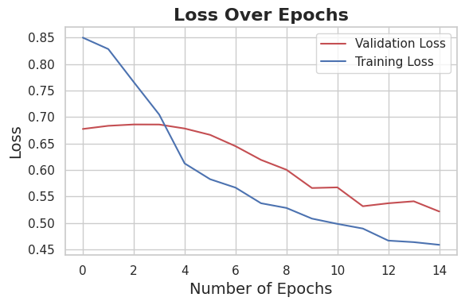

```python
plt.figure(figsize=(6, 4))
# Plot train and validation loss with a color palette
sns.lineplot(x=range(len(history.history['val_loss'])), y=history.history['val_loss'], color='r', label="Validation Loss")
sns.lineplot(x=range(len(history.history['loss'])), y=history.history['loss'], color='b', label="Training Loss")
# Add titles and labels with improved styling
plt.title("Loss Over Epochs", fontsize=16, weight='bold')
plt.xlabel("Number of Epochs", fontsize=14)
plt.ylabel("Loss", fontsize=14)
# Add gridlines and legend
plt.grid(True)
plt.legend()
# Show the plot
plt.tight_layout()
plt.show()
```

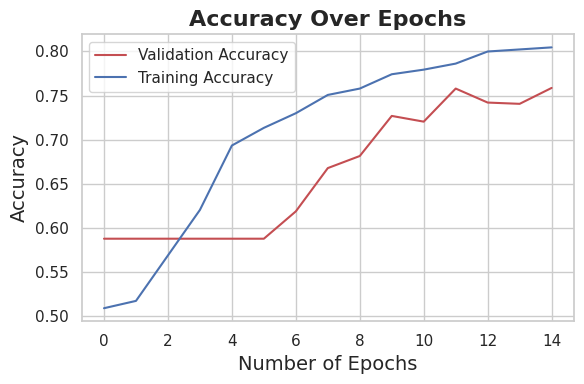

```python
plt.figure(figsize=(6, 4))
# Plot train and validation loss with a color palette
sns.lineplot(x=range(len(history.history['val_accuracy'])), y=history.history['val_accuracy'], color='r', label="Validation Accuracy")
sns.lineplot(x=range(len(history.history['accuracy'])), y=history.history['accuracy'], color='b', label="Training Accuracy")
# Add titles and labels with improved styling
plt.title("Accuracy Over Epochs", fontsize=16, weight='bold')
plt.xlabel("Number of Epochs", fontsize=14)
plt.ylabel("Accuracy", fontsize=14)
# Add gridlines and legend
plt.grid(True)
plt.legend()
# Show the plot
plt.tight_layout()
plt.show()
```

```
44/44 ━━━━━━━━━━━━━━━━━━━━ 3s 46ms/step
```

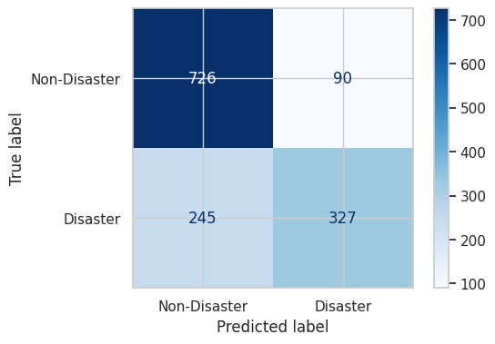

```python
from sklearn.metrics import confusion_matrix, ConfusionMatrixDisplay
# Generate predictions
y_pred_probs = model.predict(X_test)  # Replace X_test with your test data
y_pred = (y_pred_probs > 0.5).astype(int)  # Binary classification

# Compute confusion matrix
conf_matrix = confusion_matrix(y_test, y_pred)

# Visualize confusion matrix
disp = ConfusionMatrixDisplay(conf_matrix, display_labels=['Non-Disaster', 'Disaster'])
disp.plot(cmap=plt.cm.Blues, values_format='d')

# Show the plot
plt.show()
```

> - El modelo ha identificado correctamente 726 casos como negativos (tweets de no desastre) y 327 casos como positivos (tweets de desastre).
> - Sin embargo, ha cometido 90 errores al clasificar casos negativos como positivos (falsos positivos) y 245 errores al clasificar casos positivos como negativos (falsos negativos).

```python
score = model.evaluate(X_train, y_train, verbose = 0)
print('Accuracy over the training set:', round((score[1]*100), 2), '%')
```

```
Accuracy over the training set: 88.74 %
```

```python
score = model.evaluate(X_test, y_test, verbose = 0)
print('Accuracy over the test set:', round((score[1]*100), 2), '%')
```

```
Accuracy over the test set: 75.86 %
```

**Observaciones 💡 -->**

> - El modelo muestra una buena precisión en el conjunto de entrenamiento y una precisión aceptable en el conjunto de prueba. La diferencia entre la precisión en los conjuntos de entrenamiento y prueba es significativa, lo que puede indicar la existencia de sobreajuste y la necesidad de ajustar el modelo para mejorar la generalización.
> - Sabemos que hay un fuerte desbalance entre las clases, lo cual se refleja claramente en estos resultados. Aunque la precisión global del modelo es relativamente alta, esto se debe en gran parte a su capacidad para identificar correctamente los casos negativos, con 726 aciertos. Sin embargo, los aciertos en los casos positivos son significativamente menores, con solo 327 casos correctamente clasificados frente a 245 errores de clasificación de positivos como negativos. Este desbalance en los datos está influyendo en la métrica de precisión, dando una impresión exagerada de su rendimiento general. Para abordar este problema y mejorar la capacidad del modelo para identificar correctamente los casos positivos, se implementarán técnicas de aumento de datos y regularización.

##### **(3) Prueba de Clasificaciones**

```python
# Define a function to preprocess text
def preprocess_text(text, tokenizer, max_len):
    sequence = tokenizer.texts_to_sequences([text])
    padded_sequence = pad_sequences(sequence, maxlen=max_len)
    return padded_sequence
```

```python
# Make predictions
def make_predictions(model, tweets):
  for text in tweets:
      padded_sequence = preprocess_text(text, tokenizer, max_len)
      prediction_prob = model.predict(padded_sequence)[0][0]
      prediction = (prediction_prob > 0.5).astype(int)
      print(f"Text: {text}")
      print(f"Probability: {prediction_prob:.4f}")
      print(f"Prediction: {'Disaster' if prediction == 1 else 'Non-Disaster'}\n")
```

```python
# Test inputs
tweets = [
    "Emergency services are on high alert due to the approaching storm",
    "Our team had a productive meeting this morning discussing new project ideas",
    "He loves playing guitar and composing his own music",
    "Authorities are warning about severe thunderstorms in the area tonight",
    "Firefighters are working hard to contain the wildfires spreading across the region",
]
```

```python
make_predictions(model=model, tweets=tweets)
```

```
1/1 ━━━━━━━━━━━━━━━━━━━━ 0s 37ms/step
Text: Emergency services are on high alert due to the approaching storm
Probability: 0.5126
Prediction: Disaster

1/1 ━━━━━━━━━━━━━━━━━━━━ 0s 37ms/step
Text: Our team had a productive meeting this morning discussing new project ideas
Probability: 0.2515
Prediction: Non-Disaster

1/1 ━━━━━━━━━━━━━━━━━━━━ 0s 36ms/step
Text: He loves playing guitar and composing his own music
Probability: 0.2515
Prediction: Non-Disaster

1/1 ━━━━━━━━━━━━━━━━━━━━ 0s 39ms/step
Text: Authorities are warning about severe thunderstorms in the area tonight
Probability: 0.7977
Prediction: Disaster

1/1 ━━━━━━━━━━━━━━━━━━━━ 0s 39ms/step
Text: Firefighters are working hard to contain the wildfires spreading across the region
Probability: 0.2515
Prediction: Non-Disaster
```

**Observaciones 💡 -->**

> - El modelo muestra un buen desempeño en la mayoría de las predicciones, pero hay casos en los que la clasificación es errónea, especialmente para textos que claramente deberían ser clasificados como desastres. Esto se relaciona con todo lo discutido con anterioridad.

#### **(2) Second Iteration (LSTM and Data Augmentation)**

##### **(1) Data Augmentation: Synonym Replacement and Random Swapping Techniques**

```python
import nlpaug.augmenter.char as nac  # Character-level text augmentation
import nlpaug.augmenter.word as naw  # Word-level text augmentation
import nlpaug.augmenter.sentence as nas  # Sentence-level text augmentation
import nlpaug.flow as naf  # Pipeline for combining multiple augmentations
from nlpaug.util import Action  # Utilities and constants for augmentation actions
```

```python
# Upload files from the local system to the Colab environment
uploaded = files.upload()
# Iterate over the files uploaded by the user
for fn in uploaded.keys():
    # Print information about each uploaded file, including its name and size in bytes
    print('User uploaded file "{name}" with length {length} bytes'.format(
        name=fn, length=len(uploaded[fn])))
# Create the directory ~/.kaggle if it does not exist. This directory is where Kaggle API expects configuration files.
!mkdir -p ~/.kaggle/
# Move the uploaded kaggle.json file into the ~/.kaggle/ directory. This file contains API credentials for Kaggle.
!mv kaggle.json ~/.kaggle/
# Set the permissions of kaggle.json to be readable only by the owner. This is necessary for security reasons.
!chmod 600 ~/.kaggle/kaggle.json
```

Upload widget is only available when the cell has been executed in the current browser session. Please rerun this cell to enable.

```
Saving kaggle.json to kaggle.json
User uploaded file "kaggle.json" with length 68 bytes
```

```python
#!kaggle competitions download -c nlp-getting-started
#!kaggle datasets download -d rtatman/glove-global-vectors-for-word-representation
```

```python
#!unzip /content/glove-global-vectors-for-word-representation.zip
```

```python
# Initialize the WordEmbsAug augmenter with the specified model and parameters.
aug_w2v = naw.WordEmbsAug(
    # Choose the type of word embedding model to use. Options include:
    # 'word2vec', 'glove', or 'fasttext'
    model_type='glove',  # Currently set to 'glove'

    # Provide the path to the pre-trained word embeddings file.
    # The file should match the model_type selected.
    model_path='/content/glove.6B.100d.txt',  # Path to the GloVe embeddings file

    # Specify the action for augmentation. 'substitute' will replace words in the text
    # with their synonyms based on the word embeddings model.
    action="substitute"  # Action to perform; 'substitute' replaces words with synonyms
)
```

```python
from tqdm import tqdm
from sklearn.utils import shuffle

def augment_text(df, samples=600, pr=0.2):
    # Set the probability for word2vec augmentation
    aug_w2v.aug_p = pr
    new_text = []

    # Select the minority class samples (target == 1)
    df_n = df[df.target == 1].reset_index(drop=True)

    # Data augmentation loop
    for i in tqdm(np.random.randint(0, len(df_n), samples)):
        text = df_n.iloc[i]['text']
        augmented_text = aug_w2v.augment(text)
        new_text.append(augmented_text)

    # Create a DataFrame for the augmented data
    new_df = pd.DataFrame({'text': new_text, 'target': 1})

    # Combine the original and augmented data, and shuffle
    augmented_df = shuffle(pd.concat([df, new_df]).reset_index(drop=True))

    return augmented_df
```

> - **Referencia**: https://neptune.ai/blog/data-augmentation-nlp

```python
augmented_df = augment_text(df)
```

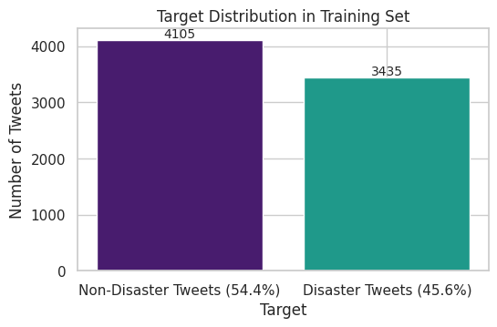

```python
# Create a figure with a single subplot
fig, ax = plt.subplots(figsize=(6, 4), dpi=100)  # Use subplots() to get the Axes object
plt.tight_layout(pad=3.0)  # Add padding around the plot

# Calculate target counts and percentages
target_counts = augmented_df['target'].value_counts()
total_count = target_counts.sum()
labels = [f'Non-Disaster Tweets ({target_counts[0]/total_count:.1%})',
          f'Disaster Tweets ({target_counts[1]/total_count:.1%})']

# Plot bar chart for target distribution with customized colors
bars = ax.bar(target_counts.index, target_counts, color=colors)

# Add labels above bars
for bar, label in zip(bars, target_counts):
    height = bar.get_height()
    ax.text(bar.get_x() + bar.get_width() / 2, height, f'{label}',
            ha='center', va='bottom', fontsize=10)

# Set labels for x-axis and y-axis
ax.set_xticks(target_counts.index)
ax.set_xticklabels(labels)
ax.set_xlabel('Target')
ax.set_ylabel('Number of Tweets')

# Set the title
ax.set_title('Target Distribution in Training Set')

# Display the plot
plt.show()
```

##### **(2) Embedding and Tokenization of Tweets**

```python
texts = augmented_df['text'].values
labels = augmented_df['target'].values
```

```python
tokenizer = Tokenizer(num_words=max_words)
tokenizer.fit_on_texts(texts)
sequences = tokenizer.texts_to_sequences(texts)
X = pad_sequences(sequences, maxlen=max_len)
```

##### **(3) Data Splitting Process**

```python
# Split into train and test sets
X_train, X_test, y_train, y_test = train_test_split(X, labels, test_size=0.2, random_state=random_state)
```

##### **(4) Model Development and Creation**

```python
from tensorflow.keras.regularizers import l2

# Define the model
model = Sequential()

# Embedding layer
model.add(Embedding(input_dim=max_words, output_dim=32, input_length=max_len))  # Increased output_dim

# Bidirectional LSTM layers with increased units
model.add(Bidirectional(LSTM(32, return_sequences=True, kernel_regularizer=l2(0.01))))  # Increased units
model.add(Bidirectional(LSTM(32, kernel_regularizer=l2(0.01))))  # Increased units

# Dense layers with regularization
model.add(Dense(36, activation='relu', kernel_regularizer=l2(0.01)))  # Increased units
model.add(Dropout(0.5))
model.add(BatchNormalization())

model.add(Dense(18, activation='relu', kernel_regularizer=l2(0.01)))  # Increased units
model.add(Dropout(0.5))
model.add(BatchNormalization())

model.add(Dense(1, activation='sigmoid'))  # Binary classification

# Explicitly build the model
model.build(input_shape=(None, max_len))
```

```python
# Define the optimizer
opt = keras.optimizers.Adam(learning_rate=0.0001, beta_1=0.9, beta_2=0.999)
```

```python
# Compile the model
model.compile(optimizer = opt, loss = "binary_crossentropy" , metrics=["accuracy"])
```

```python
# Model summary to check the architecture
model.summary()
```

```
Model: "sequential_4"
```

```
┏━━━━━━━━━━━━━━━━━━━━━━━━━━━━━━━━━━━━━━┳━━━━━━━━━━━━━━━━━━━━━━━━━━━━━┳━━━━━━━━━━━━━━━━━┓
┃ Layer (type)                         ┃ Output Shape                ┃         Param # ┃
┡━━━━━━━━━━━━━━━━━━━━━━━━━━━━━━━━━━━━━━╇━━━━━━━━━━━━━━━━━━━━━━━━━━━━━╇━━━━━━━━━━━━━━━━━┩
│ embedding_4 (Embedding)              │ (None, 127, 32)             │         320,000 │
├──────────────────────────────────────┼─────────────────────────────┼─────────────────┤
│ bidirectional_8 (Bidirectional)      │ (None, 127, 64)             │          16,640 │
├──────────────────────────────────────┼─────────────────────────────┼─────────────────┤
│ bidirectional_9 (Bidirectional)      │ (None, 64)                  │          24,832 │
├──────────────────────────────────────┼─────────────────────────────┼─────────────────┤
│ dense_12 (Dense)                     │ (None, 36)                  │           2,340 │
├──────────────────────────────────────┼─────────────────────────────┼─────────────────┤
│ dropout_8 (Dropout)                  │ (None, 36)                  │               0 │
├──────────────────────────────────────┼─────────────────────────────┼─────────────────┤
│ batch_normalization_8                │ (None, 36)                  │             144 │
│ (BatchNormalization)                 │                             │                 │
├──────────────────────────────────────┼─────────────────────────────┼─────────────────┤
│ dense_13 (Dense)                     │ (None, 18)                  │             666 │
├──────────────────────────────────────┼─────────────────────────────┼─────────────────┤
│ dropout_9 (Dropout)                  │ (None, 18)                  │               0 │
├──────────────────────────────────────┼─────────────────────────────┼─────────────────┤
│ batch_normalization_9                │ (None, 18)                  │              72 │
│ (BatchNormalization)                 │                             │                 │
├──────────────────────────────────────┼─────────────────────────────┼─────────────────┤
│ dense_14 (Dense)                     │ (None, 1)                   │              19 │
└──────────────────────────────────────┴─────────────────────────────┴─────────────────┘
```

```
 Total params: 364,713 (1.39 MB)
```

```
 Trainable params: 364,605 (1.39 MB)
```

```
 Non-trainable params: 108 (432.00 B)
```

**Observaciones 💡 -->**

> - Se añadió regularización L2 (l2 = 0.01) a las capas Dense y LSTM para ayudar disminuir el sobreajuste evidenciado en el modelo anterior.
> - Se aumentaron la cantidad de neuronas en algunas capas para mejorar el rendimiento del modelo.

##### **(5) Entrenamiento**

```python
# Fit the model
history = model.fit(X_train, y_train,
                    epochs = epochs, validation_data = (X_test, y_test), batch_size = X_train.shape[0] // batch_size,
                    callbacks=[early_stopping])
```

```
65/65 ━━━━━━━━━━━━━━━━━━━━ 38s 386ms/step - accuracy: 0.5137 - loss: 4.2520 - val_accuracy: 0.5597 - val_loss: 3.8527
65/65 ━━━━━━━━━━━━━━━━━━━━ 40s 365ms/step - accuracy: 0.5115 - loss: 3.9764 - val_accuracy: 0.5597 - val_loss: 3.6250
65/65 ━━━━━━━━━━━━━━━━━━━━ 24s 367ms/step - accuracy: 0.5107 - loss: 3.7285 - val_accuracy: 0.5597 - val_loss: 3.4170
65/65 ━━━━━━━━━━━━━━━━━━━━ 40s 354ms/step - accuracy: 0.5339 - loss: 3.4952 - val_accuracy: 0.5597 - val_loss: 3.2248
65/65 ━━━━━━━━━━━━━━━━━━━━ 24s 360ms/step - accuracy: 0.5531 - loss: 3.2847 - val_accuracy: 0.6200 - val_loss: 3.0459
65/65 ━━━━━━━━━━━━━━━━━━━━ 40s 346ms/step - accuracy: 0.5951 - loss: 3.0452 - val_accuracy: 0.6001 - val_loss: 2.8904
65/65 ━━━━━━━━━━━━━━━━━━━━ 39s 322ms/step - accuracy: 0.6407 - loss: 2.7912 - val_accuracy: 0.5869 - val_loss: 2.7427
65/65 ━━━━━━━━━━━━━━━━━━━━ 41s 316ms/step - accuracy: 0.6960 - loss: 2.5937 - val_accuracy: 0.6810 - val_loss: 2.5992
65/65 ━━━━━━━━━━━━━━━━━━━━ 41s 325ms/step - accuracy: 0.7097 - loss: 2.4589 - val_accuracy: 0.7480 - val_loss: 2.4450
65/65 ━━━━━━━━━━━━━━━━━━━━ 41s 337ms/step - accuracy: 0.7374 - loss: 2.2986 - val_accuracy: 0.7533 - val_loss: 2.3097
65/65 ━━━━━━━━━━━━━━━━━━━━ 41s 334ms/step - accuracy: 0.7556 - loss: 2.1777 - val_accuracy: 0.7527 - val_loss: 2.1682
65/65 ━━━━━━━━━━━━━━━━━━━━ 41s 331ms/step - accuracy: 0.7891 - loss: 2.0459 - val_accuracy: 0.7606 - val_loss: 2.0596
65/65 ━━━━━━━━━━━━━━━━━━━━ 22s 338ms/step - accuracy: 0.8052 - loss: 1.9389 - val_accuracy: 0.7527 - val_loss: 1.9592
65/65 ━━━━━━━━━━━━━━━━━━━━ 40s 330ms/step - accuracy: 0.8228 - loss: 1.8181 - val_accuracy: 0.7427 - val_loss: 1.8900
65/65 ━━━━━━━━━━━━━━━━━━━━ 42s 346ms/step - accuracy: 0.8257 - loss: 1.7363 - val_accuracy: 0.7447 - val_loss: 1.8097
```

**Observaciones 💡 -->**

##### **(6) Evaluación de Desempeño**

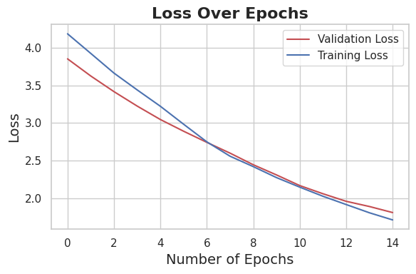

```python
plt.figure(figsize=(6, 4))
# Plot train and validation loss with a color palette
sns.lineplot(x=range(len(history.history['val_loss'])), y=history.history['val_loss'], color='r', label="Validation Loss")
sns.lineplot(x=range(len(history.history['loss'])), y=history.history['loss'], color='b', label="Training Loss")
# Add titles and labels with improved styling
plt.title("Loss Over Epochs", fontsize=16, weight='bold')
plt.xlabel("Number of Epochs", fontsize=14)
plt.ylabel("Loss", fontsize=14)
# Add gridlines and legend
plt.grid(True)
plt.legend()
# Show the plot
plt.tight_layout()
plt.show()
```

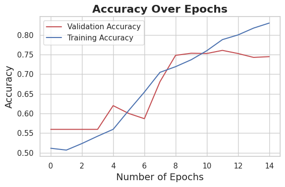

```python
plt.figure(figsize=(6, 4))
# Plot train and validation loss with a color palette
sns.lineplot(x=range(len(history.history['val_accuracy'])), y=history.history['val_accuracy'], color='r', label="Validation Accuracy")
sns.lineplot(x=range(len(history.history['accuracy'])), y=history.history['accuracy'], color='b', label="Training Accuracy")
# Add titles and labels with improved styling
plt.title("Accuracy Over Epochs", fontsize=16, weight='bold')
plt.xlabel("Number of Epochs", fontsize=14)
plt.ylabel("Accuracy", fontsize=14)
# Add gridlines and legend
plt.grid(True)
plt.legend()
# Show the plot
plt.tight_layout()
plt.show()
```

```
48/48 ━━━━━━━━━━━━━━━━━━━━ 3s 72ms/step
```

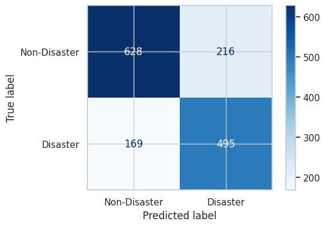

```python
# Generate predictions
y_pred_probs = model.predict(X_test)  # Replace X_test with your test data
y_pred = (y_pred_probs > 0.5).astype(int)  # Binary classification

# Compute confusion matrix
conf_matrix = confusion_matrix(y_test, y_pred)

# Visualize confusion matrix
disp = ConfusionMatrixDisplay(conf_matrix, display_labels=['Non-Disaster', 'Disaster'])
disp.plot(cmap=plt.cm.Blues, values_format='d')

# Show the plot
plt.show()
```

> - El modelo ha identificado correctamente 628 casos como negativos (tweets que no se refieren a desastres) y 495 casos como positivos (tweets que se refieren a desastres).
> - No obstante, ha cometido 216 errores al clasificar casos negativos como positivos (falsos positivos) y 169 errores al clasificar casos positivos como negativos (falsos negativos).
> - ES importante notar que parece ser que gracias al balanceo de clases, el modelo ahora es capaz de reconocer más tweets de desastres que antes.

```python
score = model.evaluate(X_train, y_train, verbose = 0)
print('Accuracy over the training set:', round((score[1]*100), 2), '%')
```

```
Accuracy over the training set: 91.94 %
```

```python
score = model.evaluate(X_test, y_test, verbose = 0)
print('Accuracy over the test set:', round((score[1]*100), 2), '%')
```

```
Accuracy over the test set: 74.47 %
```

**Observaciones 💡 -->**

En general, el nuevo modelo muestra un buen desempeño en el conjunto de entrenamiento, pero su precisión en el conjunto de prueba es más baja. Esto sugiere que, aunque el modelo está bien ajustado a los datos de entrenamiento, podría beneficiarse de técnicas adicionales para mejorar su capacidad de generalización. Sin emabrgo, es evidente que ha mejorado grandemente su capacidad de clasificar correctamente los tweets de desastre, comparado con el modelo anterior.

```python
make_predictions(model=model, tweets=tweets)
```

```
1/1 ━━━━━━━━━━━━━━━━━━━━ 0s 39ms/step
Text: Emergency services are on high alert due to the approaching storm
Probability: 0.8125
Prediction: Disaster

1/1 ━━━━━━━━━━━━━━━━━━━━ 0s 36ms/step
Text: Our team had a productive meeting this morning discussing new project ideas
Probability: 0.1439
Prediction: Non-Disaster

1/1 ━━━━━━━━━━━━━━━━━━━━ 0s 36ms/step
Text: He loves playing guitar and composing his own music
Probability: 0.2297
Prediction: Non-Disaster

1/1 ━━━━━━━━━━━━━━━━━━━━ 0s 37ms/step
Text: Authorities are warning about severe thunderstorms in the area tonight
Probability: 0.7734
Prediction: Disaster

1/1 ━━━━━━━━━━━━━━━━━━━━ 0s 36ms/step
Text: Firefighters are working hard to contain the wildfires spreading across the region
Probability: 0.6358
Prediction: Disaster
```

**Observaciones 💡 -->**

**Nota:** Basándose en lo anteriormente expuesto, se concluye que el mejor modelo para la clasificación de tweets de desastre es el modelo **LSTM con Regularización y Data Augmentation**.

## **(5) Testing Classification Capabilities with Our Custom Function**

```python
# Test inputs
tweets = [
    "Authorities are investigating a tragic mass murder that occurred in the city center",
    "Authorities are investigating a tragic bombing that occurred in the city center",
    "I had a great time at the concert last night with my friends",
    "Local volunteers are organizing a charity event to support victims of recent disasters",
    "Health officials are advising caution due to a recent outbreak of flu",
    "Students at the university are preparing for their upcoming exams and final projects",
]
```

```python
make_predictions(model=model, tweets=tweets)
```

```
1/1 ━━━━━━━━━━━━━━━━━━━━ 0s 38ms/step
Text: Authorities are investigating a tragic mass murder that occurred in the city center
Probability: 0.7014
Prediction: Disaster

1/1 ━━━━━━━━━━━━━━━━━━━━ 0s 42ms/step
Text: Authorities are investigating a tragic bombing that occurred in the city center
Probability: 0.3910
Prediction: Non-Disaster

1/1 ━━━━━━━━━━━━━━━━━━━━ 0s 38ms/step
Text: I had a great time at the concert last night with my friends
Probability: 0.1704
Prediction: Non-Disaster

1/1 ━━━━━━━━━━━━━━━━━━━━ 0s 36ms/step
Text: Local volunteers are organizing a charity event to support victims of recent disasters
Probability: 0.2942
Prediction: Non-Disaster

1/1 ━━━━━━━━━━━━━━━━━━━━ 0s 36ms/step
Text: Health officials are advising caution due to a recent outbreak of flu
Probability: 0.7593
Prediction: Disaster

1/1 ━━━━━━━━━━━━━━━━━━━━ 0s 37ms/step
Text: Students at the university are preparing for their upcoming exams and final projects
Probability: 0.3712
Prediction: Non-Disaster
```

**Observaciones 💡 -->**

> - En general, el nuevo modelo muestra un desempeño más sólido en la clasificación de eventos graves en comparación con el modelo anterior. Por ejemplo, predice correctamente eventos como "Authorities are investigating a tragic mass murder that occurred in the city center" con una probabilidad alta de 0.7014, indicando una buena capacidad para clasificar desastres graves.
> - Sin embargo, también muestra algunas debilidades; por ejemplo, clasifica incorrectamente un texto sobre una tragedia de bombardeo como "No Desastre" con una probabilidad de 0.3910, sugiriendo que el modelo puede estar subestimando la gravedad de ciertos eventos.
> - Finalmente, el modelo identifica correctamente eventos no relacionados con desastres, como actividades recreativas y académicas, con probabilidades bajas, lo que refuerza su capacidad para distinguir entre texto relevante y no relevante para desastres.